# Study of Longley dataset

# Introduction

### In our Mathematics for Data Science course, we had to do the analysis of a dataset. The goal for us is to be able to understand the process and be able to do it by ourselves later.

### Therefore, we will work on the dataset Longley on R.

# Data Exploration

### The dataset Longley stores data from the United State between 1947 and 1962. It regroups the GNP (Gross National Product) and its deflator, the number of unemployed people, in the armed forces and employed (in 1000s). It also contains the number of people above 14-years old and non-institutionalized (in 1000s), basically undocumented adults and teenagers.

### There is two important events which took place during the period of time recorded by our dataset: the Korea War (1950 – 1953) and the Indochina War (1954 – 1975). These wars were important enough to have an impact on the life of the population at this time so we can imagine they would have influenced our data in some way.

# Data Visualization

### First of all, we have to look at what our data look like.

```r
longley
```

```
##      GNP.deflator     GNP Unemployed Armed.Forces Population Year Employed
## 1947         83.0 234.289      235.6        159.0    107.608 1947   60.323
## 1948         88.5 259.426      232.5        145.6    108.632 1948   61.122
## 1949         88.2 258.054      368.2        161.6    109.773 1949   60.171
## 1950         89.5 284.599      335.1        165.0    110.929 1950   61.187
## 1951         96.2 328.975      209.9        309.9    112.075 1951   63.221
## 1952         98.1 346.999      193.2        359.4    113.270 1952   63.639
## 1953         99.0 365.385      187.0        354.7    115.094 1953   64.989
## 1954        100.0 363.112      357.8        335.0    116.219 1954   63.761
## 1955        101.2 397.469      290.4        304.8    117.388 1955   66.019
## 1956        104.6 419.180      282.2        285.7    118.734 1956   67.857
## 1957        108.4 442.769      293.6        279.8    120.445 1957   68.169
## 1958        110.8 444.546      468.1        263.7    121.950 1958   66.513
## 1959        112.6 482.704      381.3        255.2    123.366 1959   68.655
## 1960        114.2 502.601      393.1        251.4    125.368 1960   69.564
## 1961        115.7 518.173      480.6        257.2    127.852 1961   69.331
## 1962        116.9 554.894      400.7        282.7    130.081 1962   70.551
```

### Even if we can not conclude something from the table like this, we can state some evolutions. For example, the GNP deflator is a positive straight line and there is an increase of the size of the armed forces in 1951.

### Using the summary method, we can go further in our visualization

```r
#GNP deflator
summary(longley $ GNP.deflator)
```

```
##    Min. 1st Qu.  Median    Mean 3rd Qu.    Max.
##   83.00   94.53  100.60  101.68  111.25  116.90
```

```r
#GNP
summary(longley $ GNP)
```

```
##    Min. 1st Qu.  Median    Mean 3rd Qu.    Max.
##   234.3   317.9   381.4   387.7   454.1   554.9
```

```r
#Unemployed
summary(longley $ Unemployed)
```

```
##    Min. 1st Qu.  Median    Mean 3rd Qu.    Max.
##   187.0   234.8   314.4   319.3   384.2   480.6
```

```r
#Armed.Forces
summary(longley $ Armed.Forces)
```

```
##    Min. 1st Qu.  Median    Mean 3rd Qu.    Max.
##   145.6   229.8   271.8   260.7   306.1   359.4
```

```r
#Population
summary(longley $ Population)
```

```
##    Min. 1st Qu.  Median    Mean 3rd Qu.    Max.
##   107.6   111.8   116.8   117.4   122.3   130.1
```

```r
#Employed
summary(longley $ Employed)
```

```
##    Min. 1st Qu.  Median    Mean 3rd Qu.    Max.
##   60.17   62.71   65.50   65.32   68.29   70.55
```

### With this, we can see there were a massive increase of unemployed people in USA during these 15 years, as well as the number of people in the armed forces. In contrary, the number of employed people did not really change, which could means there were almost zero impact by the war.

### Even if the data are still not easily readable, it allows us to make a subject and some hypothesis, as the ones below.

## Subject : The impact of the GNP on the people in the USA between 1947 and 1962

#### 1. Is there a correlation between the number of unemployed people and the ones in the armed forces?

#### 2. Is there a correlation between the GNP and the number of unemployed people?

#### 3. Is there a correlation between the GNP and the number of people in the armed forces?

#### 4. Is there a correlation between the number of people in the armed forces and the ones undocumented?

#### 5. Is there a correlation between the number of unemployed people and the ones undocumented?

#### 6. Is there a correlation between the number of undocumented people and the evolution of the GNP?

#### 7. Is there a correlation between the GNP and the number of employed people?

#### 8. Is there a correlation between the number of employed people and the number of employed people?

# Testing Hypothesis

#### We first have to import libaries to do our graphs

```r
library(ggplot2)
library("tidyverse")
library("tibble")
library("olsrr")
```

#### We also have to create a new data.frame which will be useful later

```r
newAF <- as_tibble(longley)
army <- newAF[longley $Armed.Forces >= 200,] $GNP

newGNP <- as_tibble(longley)
gnp <- newGNP[longley $GNP >= 300,] $Armed.Forces

newPop <- as_tibble(longley)
population <- newAF[longley $Population >= 111,] $Armed.Forces

unemployed <- c(209.9, 193.2, 187.0, 357.8, 290.4, 282.2, 293.6, 468.1, 381.3, 393.1, 480.6, 400.7)

newDataFrame <- data.frame(gnp, army, population, unemployed)
```

### 1) Is there a correlation between the number of unemployed people and the ones in the armed forces?

#### For the first hypothesis, we can see on the graphs below what seems like a correlation between the number of unemployed people and the number of people in the armed forces.

#### However, the p-value is superior to 0.05 so we reject the hypothesis if we do not touch our data. Nonetheless, we can distinguish two groups, so we will remodel our data to be able to work on it.

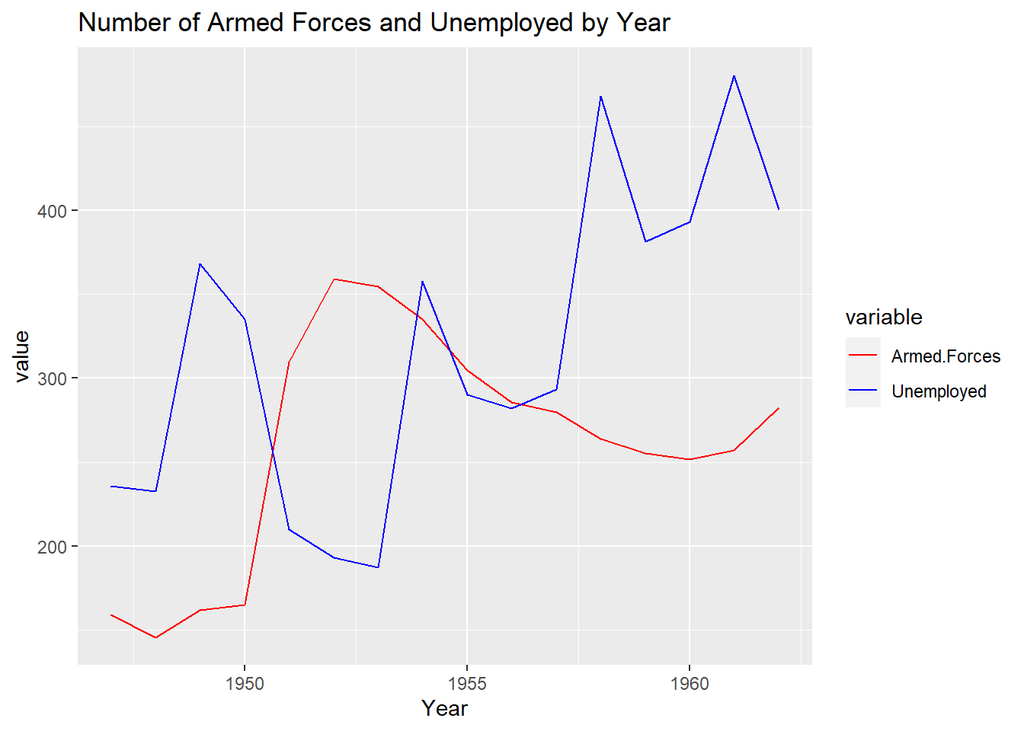

```r
df <- longley %>%
  select (Year, Unemployed, Armed.Forces) %>%
  gather(key = "variable", value = "value", -Year)


ggplot(df, aes(x = Year, y = value)) +
  geom_line(aes(color = variable)) +
  scale_color_manual(values = c("red", "blue")) +
  ggtitle("Number of Armed Forces and Unemployed by Year")
```

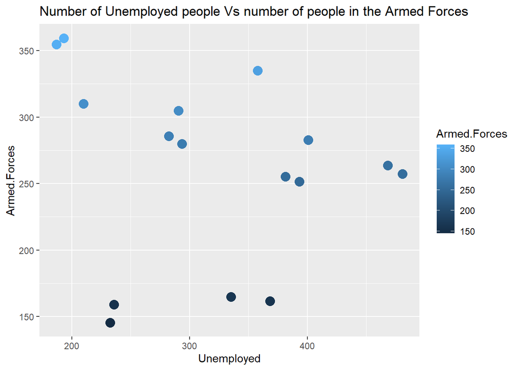

```r
ggplot(longley, aes(x = Unemployed, y = Armed.Forces, colour = Armed.Forces)) +
  geom_point(size = 4) +
  ggtitle("Number of Unemployed people Vs number of people in the Armed Forces")
```

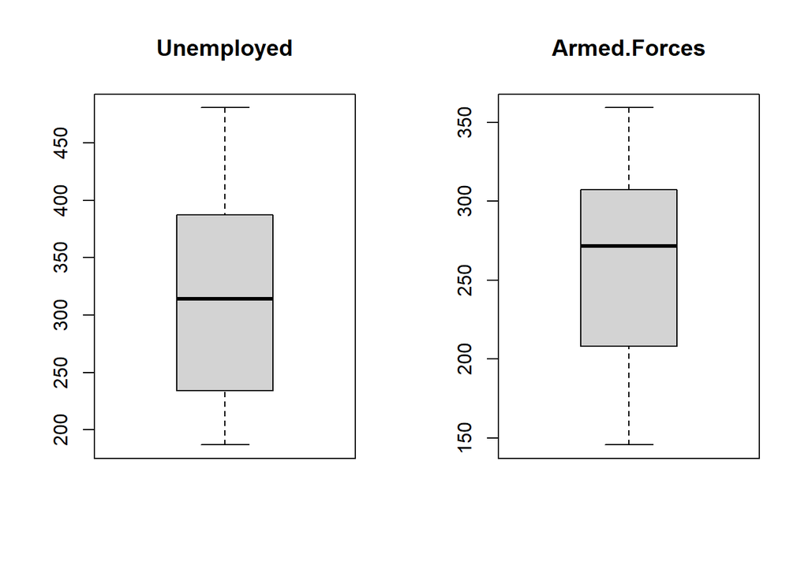

```r
par(mfrow=c(1,2))
boxplot(longley$Unemployed,main = "Unemployed")
boxplot(longley$Armed.Forces,main = "Armed.Forces")
```

```r
mod <- lm(formula = Unemployed ~ Armed.Forces, data=longley)
summary(mod)
```

```
##
## Call:
## lm(formula = Unemployed ~ Armed.Forces, data = longley)
##
## Residuals:
##     Min      1Q  Median      3Q     Max
## -114.25  -98.93  -12.72   63.39  160.44
##
## Coefficients:
##              Estimate Std. Error t value Pr(>|t|)
## (Intercept)  381.4320    95.0887   4.011  0.00129 **
## Armed.Forces  -0.2382     0.3532  -0.675  0.51095
## ---
## Signif. codes:  0 '***' 0.001 '**' 0.01 '*' 0.05 '.' 0.1 ' ' 1
##
## Residual standard error: 95.19 on 14 degrees of freedom
## Multiple R-squared:  0.03148,    Adjusted R-squared:  -0.0377
## F-statistic: 0.455 on 1 and 14 DF,  p-value: 0.5109
```

### 1) Remodelled

#### We are forced to remodel our dataset to create a good model

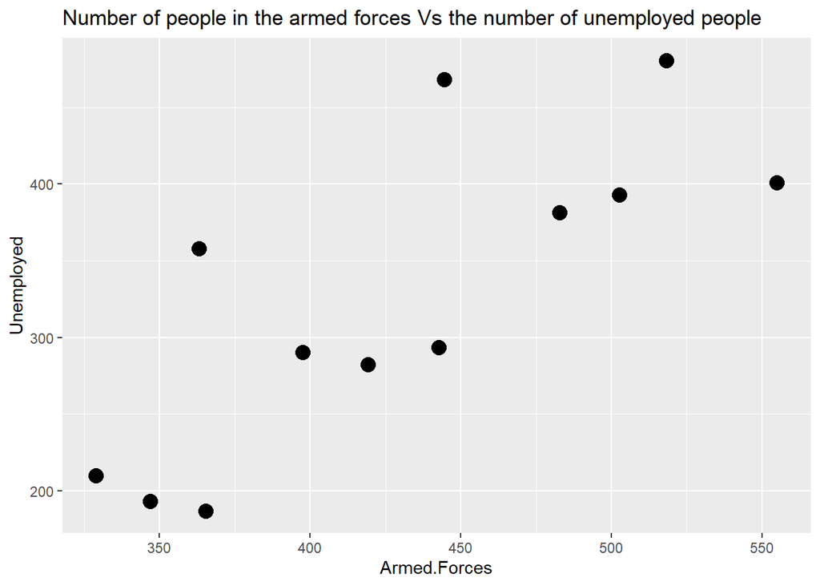

```r
ggplot(newDataFrame, aes(x = army, y = unemployed)) +
  geom_point(size = 4) +
  labs(y = "Unemployed", x = "Armed.Forces") +
  ggtitle("Number of people in the armed forces Vs the number of unemployed people")
```

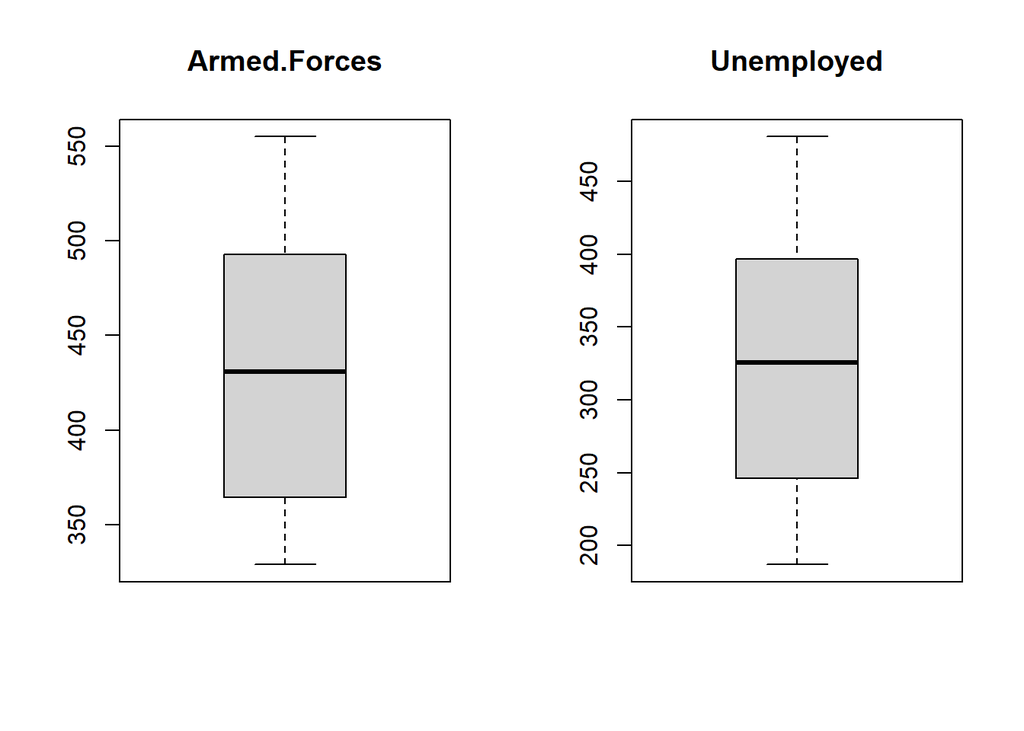

```r
par(mfrow=c(1,2))
boxplot(newDataFrame$army,main = "Armed.Forces")
boxplot(newDataFrame$unemployed,main = "Unemployed")
```

```r
mod <- lm(formula = army ~ unemployed, data=newDataFrame)
summary(mod)
```

```
##
## Call:
## lm(formula = army ~ unemployed, data = newDataFrame)
##
## Residuals:
##     Min      1Q  Median      3Q     Max
## -84.165 -17.591   8.031  24.555  83.432
##
## Coefficients:
##             Estimate Std. Error t value Pr(>|t|)
## (Intercept) 245.5729    48.6844   5.044 0.000504 ***
## unemployed    0.5637     0.1423   3.962 0.002676 **
## ---
## Signif. codes:  0 '***' 0.001 '**' 0.01 '*' 0.05 '.' 0.1 ' ' 1
##
## Residual standard error: 47.8 on 10 degrees of freedom
## Multiple R-squared:  0.6109, Adjusted R-squared:  0.572
## F-statistic:  15.7 on 1 and 10 DF,  p-value: 0.002676
```

### 2) Is there a correlation between the GNP and the number of unemployed people?

#### For the second hypothesis, we can state that, over the years, the GNP increases constantly and seems to have almost no correlation with the number of unemployed people. The only possible correlation is the fact the number of unemployed people increases dramatically when there is a little drop in the GNP produced.

#### However the hypothesis can not be rejected based on the p-value, meaning there is a correlation between these variable.

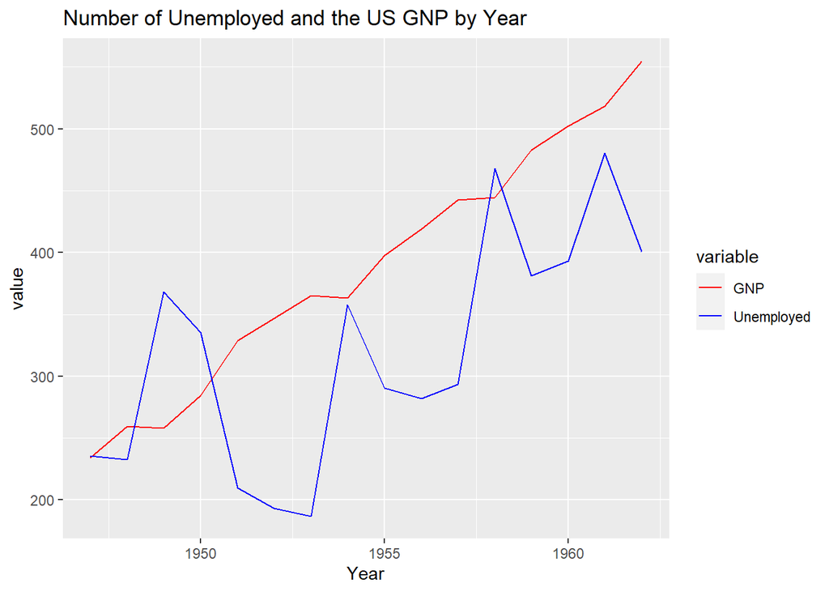

```r
df <- longley %>%
  select (Year, Unemployed, GNP) %>%
  gather(key = "variable", value = "value", -Year)

ggplot(df, aes(x = Year, y = value)) +
  geom_line(aes(color = variable)) +
  scale_color_manual(values = c("red", "blue")) +
  ggtitle("Number of Unemployed and the US GNP by Year")
```

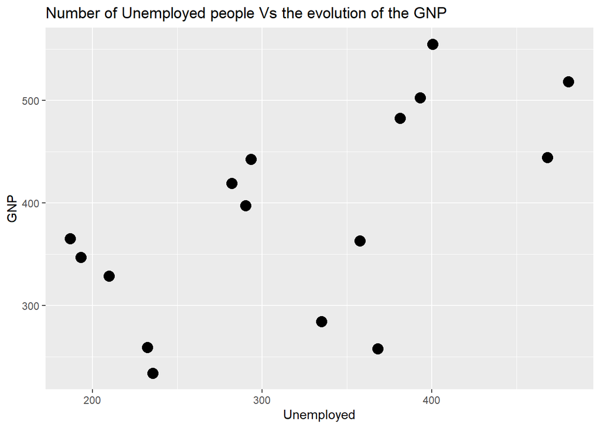

```r
ggplot(longley, aes(x = Unemployed, y = GNP)) +
  geom_point(size = 4) +
  ggtitle("Number of Unemployed people Vs the evolution of the GNP")
```

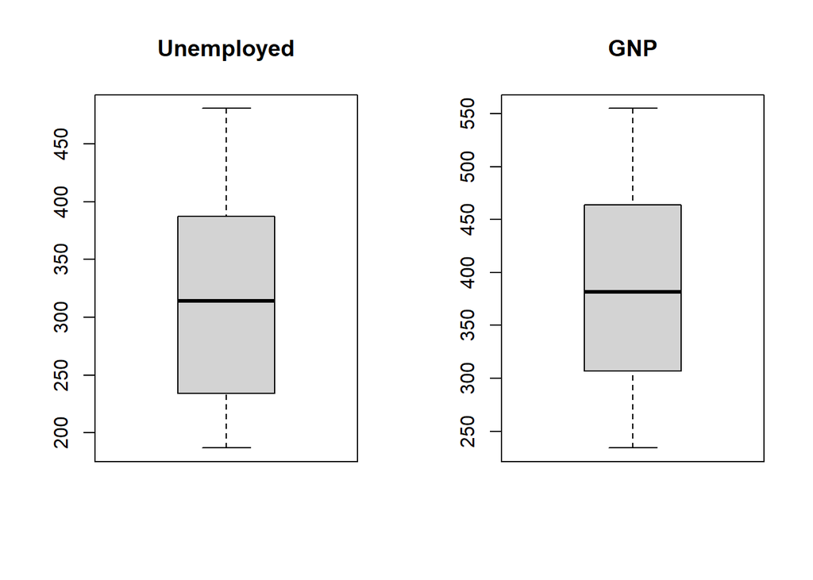

```r
par(mfrow=c(1,2))
boxplot(longley$Unemployed,main = "Unemployed")
boxplot(longley$GNP,main = "GNP")
```

```r
mod <- lm(formula = Unemployed ~ GNP, data=longley)
summary(mod)
```

```
##
## Call:
## lm(formula = Unemployed ~ GNP, data = longley)
##
## Residuals:
##      Min       1Q   Median       3Q      Max
## -119.655  -55.516   -5.097   57.912  122.519
##
## Coefficients:
##             Estimate Std. Error t value Pr(>|t|)
## (Intercept)  99.0807    79.9751   1.239   0.2358
## GNP           0.5681     0.2002   2.838   0.0132 *
## ---
## Signif. codes:  0 '***' 0.001 '**' 0.01 '*' 0.05 '.' 0.1 ' ' 1
##
## Residual standard error: 77.07 on 14 degrees of freedom
## Multiple R-squared:  0.3651, Adjusted R-squared:  0.3198
## F-statistic: 8.052 on 1 and 14 DF,  p-value: 0.01317
```

### 3) Is there a correlation between the GNP and the number of people in the armed forces?

#### For the third hypothesis, we can state without doubt there is no correlation at all between the GNP and the number of people in armed forces.

#### However, we can clearly see two groups in this graph. Therefore, this can not be analyze like this, and we have to delete some values to work on it. For this case, we delete the values under 200.

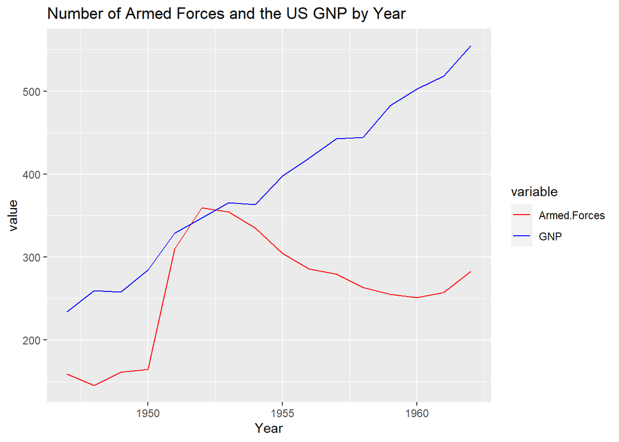

```r
df <- longley %>%
  select (Year, Armed.Forces, GNP) %>%
  gather(key = "variable", value = "value", -Year)

ggplot(df, aes(x = Year, y = value)) +
  geom_line(aes(color = variable)) +
  scale_color_manual(values = c("red", "blue")) +
  ggtitle("Number of Armed Forces and the US GNP by Year")
```

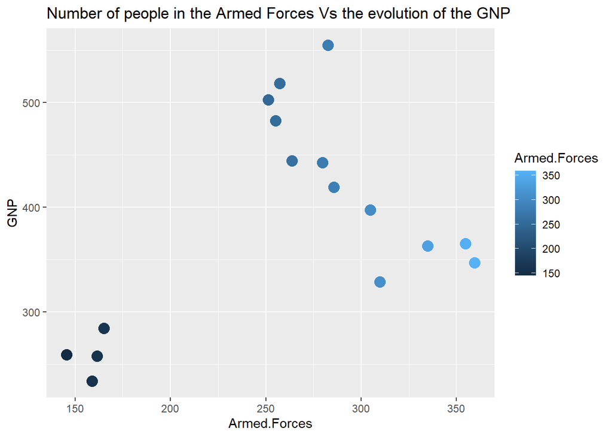

```r
ggplot(longley, aes(x = Armed.Forces, y = GNP, colour = Armed.Forces)) +
  geom_point(size = 4) +
  ggtitle("Number of people in the Armed Forces Vs the evolution of the GNP")
```

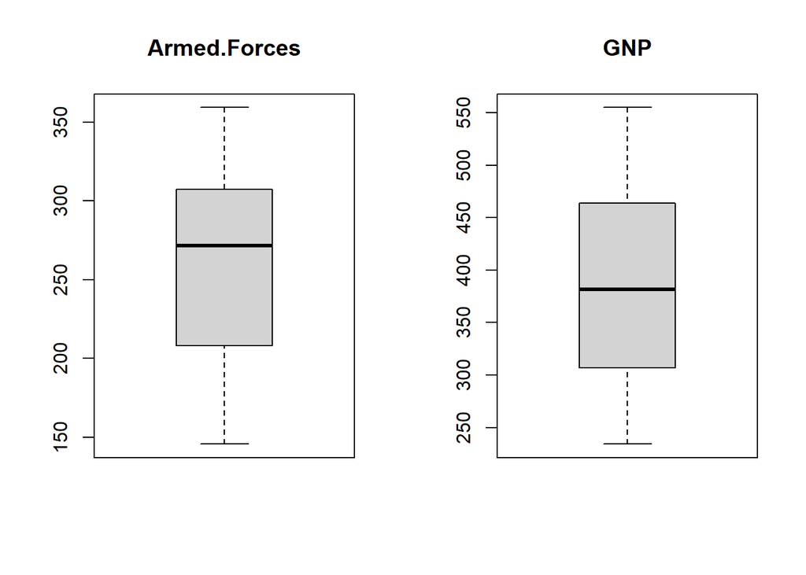

```r
par(mfrow=c(1,2))
boxplot(longley$Armed.Forces,main = "Armed.Forces")
boxplot(longley$GNP,main = "GNP")
```

### 3) Remodelled

#### We are forced to remodel our dataset to create a good model

#### We can clearly see the new model as a negative linear one, meaning there is a correlation between the number of people in the army and the evolution of the GNP. The p-value is largely under 0.05 so we can not reject the hypothesis.

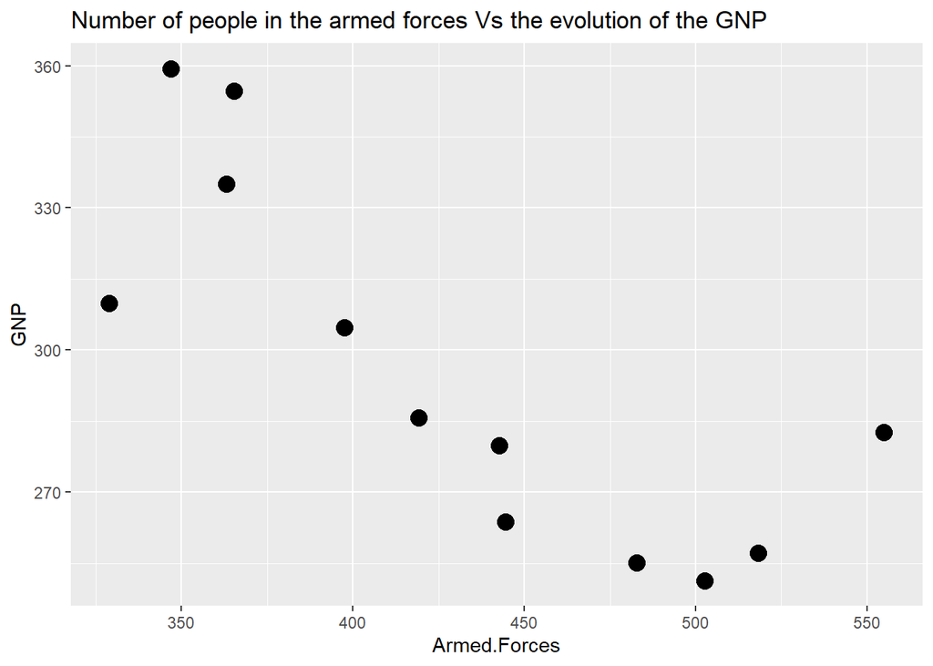

```r
ggplot(newDataFrame, aes(x = army, y = gnp)) +
  geom_point(size = 4) +
  labs(y = "GNP", x = "Armed.Forces") +
  ggtitle("Number of people in the armed forces Vs the evolution of the GNP")
```

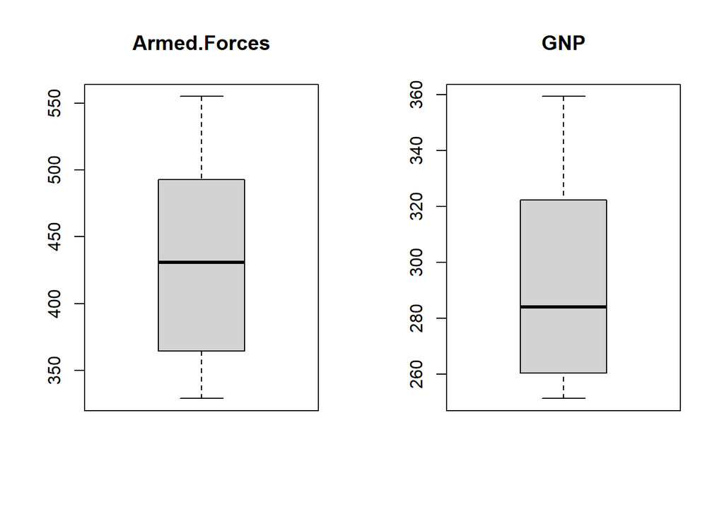

```r
par(mfrow=c(1,2))
boxplot(newDataFrame$army,main = "Armed.Forces")
boxplot(newDataFrame$gnp,main = "GNP")
```

```r
mod <- lm(formula = gnp ~ army, data=newDataFrame)
summary(mod)
```

```
##
## Call:
## lm(formula = gnp ~ army, data = newDataFrame)
##
## Residuals:
##     Min      1Q  Median      3Q     Max
## -27.249 -15.017  -6.997  16.455  39.374
##
## Coefficients:
##              Estimate Std. Error t value Pr(>|t|)
## (Intercept) 473.77214   43.60041  10.866 7.39e-07 ***
## army         -0.41530    0.09995  -4.155  0.00196 **
## ---
## Signif. codes:  0 '***' 0.001 '**' 0.01 '*' 0.05 '.' 0.1 ' ' 1
##
## Residual standard error: 24.22 on 10 degrees of freedom
## Multiple R-squared:  0.6332, Adjusted R-squared:  0.5965
## F-statistic: 17.26 on 1 and 10 DF,  p-value: 0.001964
```

### 4) Is there a correlation between the number of people in the armed forces and the ones undocumented?

#### For the fourth hypothesis, there is no correlation again between the two curbs, the number of people in armed forces and the number of undocumented people.

#### Howeber, as before, we can clearly see two groups in this graph. Therefore, this can not be analyze like this, and we have to delete some values to work on it. For this case, we delete the values under 200.

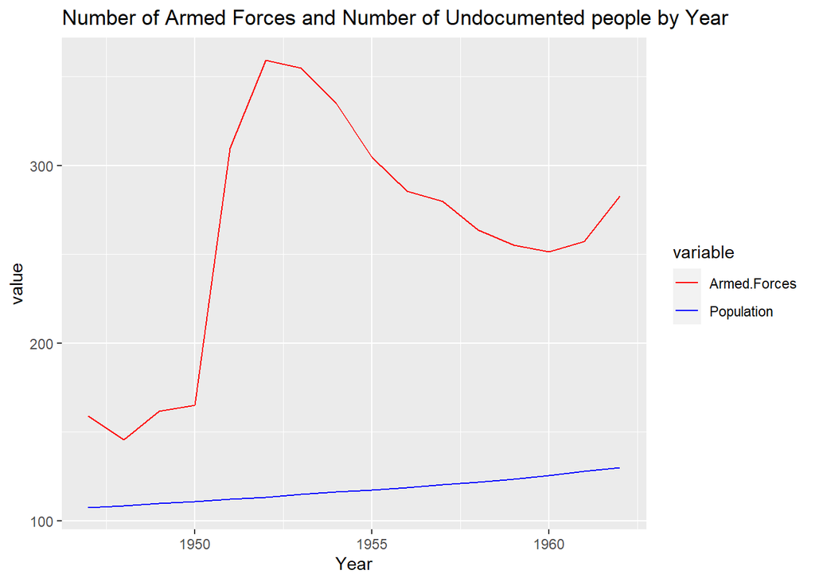

```r
df <- longley %>%
  select (Year, Armed.Forces, Population) %>%
  gather(key = "variable", value = "value", -Year)

ggplot(df, aes(x = Year, y = value)) +
  geom_line(aes(color = variable)) +
  scale_color_manual(values = c("red", "blue")) +
  ggtitle("Number of Armed Forces and Number of Undocumented people by Year")
```

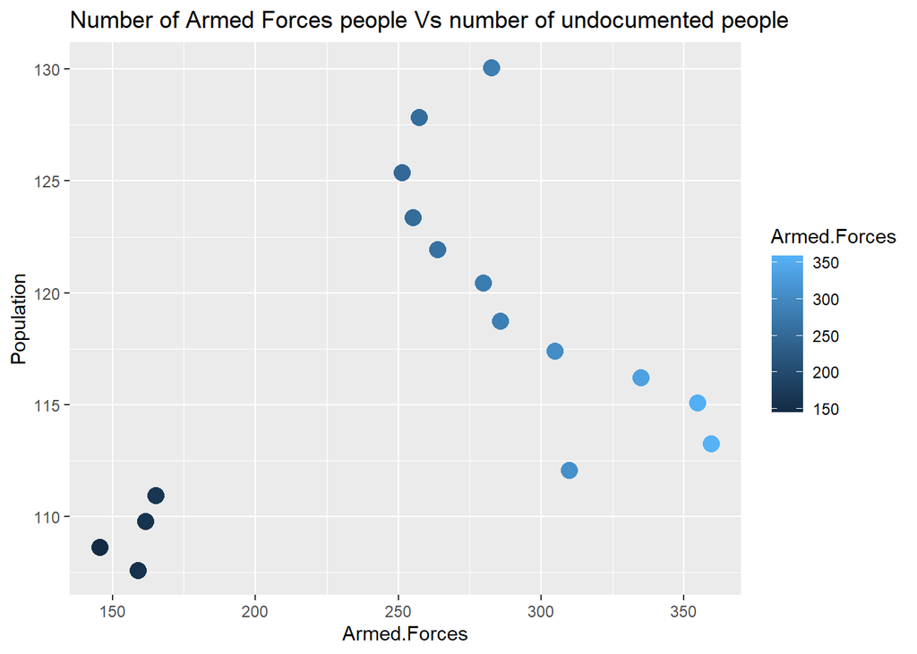

```r
ggplot(longley, aes(x = Armed.Forces, y = Population, colour = Armed.Forces)) +
  geom_point(size = 4) +
  ggtitle("Number of Armed Forces people Vs number of undocumented people")
```

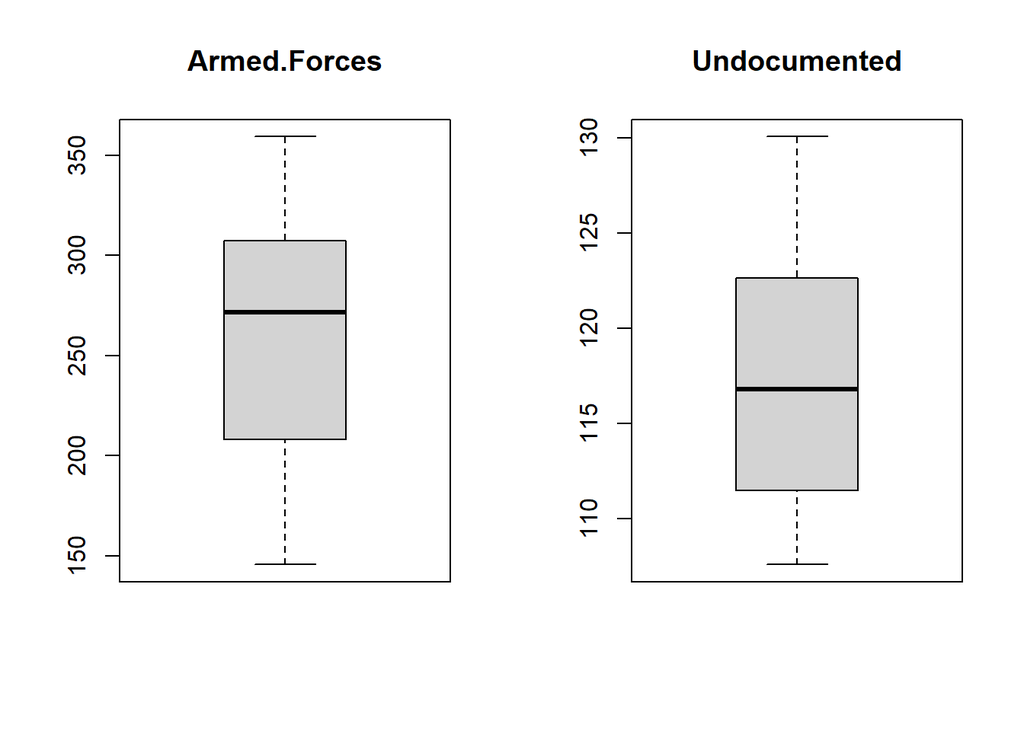

```r
par(mfrow=c(1,2))
boxplot(longley$Armed.Forces,main = "Armed.Forces")
boxplot(longley$Population,main = "Undocumented")
```

#### 4) Remodelled

#### As before, we are forced to remodel our dataset to create a good model

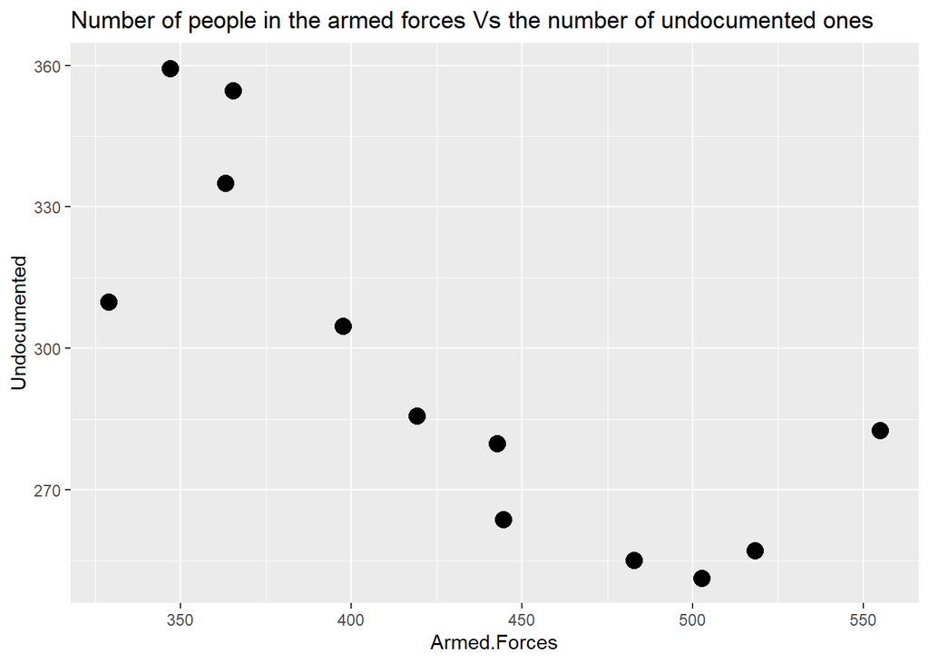

```r
ggplot(newDataFrame, aes(x = army, y = population)) +
  geom_point(size = 4) +
  labs(y = "Undocumented", x = "Armed.Forces") +
  ggtitle("Number of people in the armed forces Vs the number of undocumented ones")
```

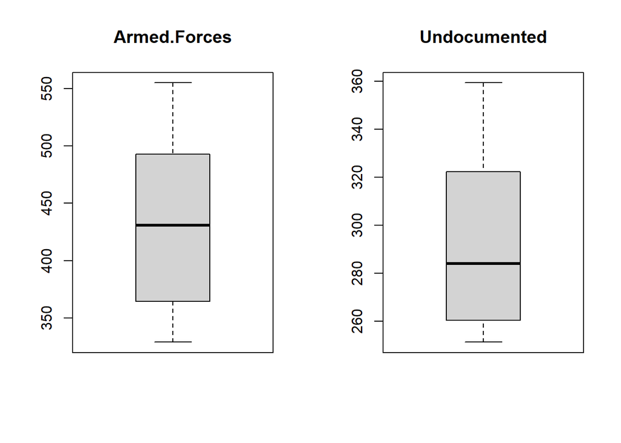

```r
par(mfrow=c(1,2))
boxplot(newDataFrame$army,main = "Armed.Forces")
boxplot(newDataFrame$population,main = "Undocumented")
```

```r
mod <- lm(formula = population ~ army, data=newDataFrame)
summary(mod)
```

```
##
## Call:
## lm(formula = population ~ army, data = newDataFrame)
##
## Residuals:
##     Min      1Q  Median      3Q     Max
## -27.249 -15.017  -6.997  16.455  39.374
##
## Coefficients:
##              Estimate Std. Error t value Pr(>|t|)
## (Intercept) 473.77214   43.60041  10.866 7.39e-07 ***
## army         -0.41530    0.09995  -4.155  0.00196 **
## ---
## Signif. codes:  0 '***' 0.001 '**' 0.01 '*' 0.05 '.' 0.1 ' ' 1
##
## Residual standard error: 24.22 on 10 degrees of freedom
## Multiple R-squared:  0.6332, Adjusted R-squared:  0.5965
## F-statistic: 17.26 on 1 and 10 DF,  p-value: 0.001964
```

### 5) Is there a correlation between the number of unemployed people and the ones undocumented?

#### However, the p-value is smaller to 0.05 by far so we can not reject the hypothesis. Therefore, there must be a correlation between these two parameters.

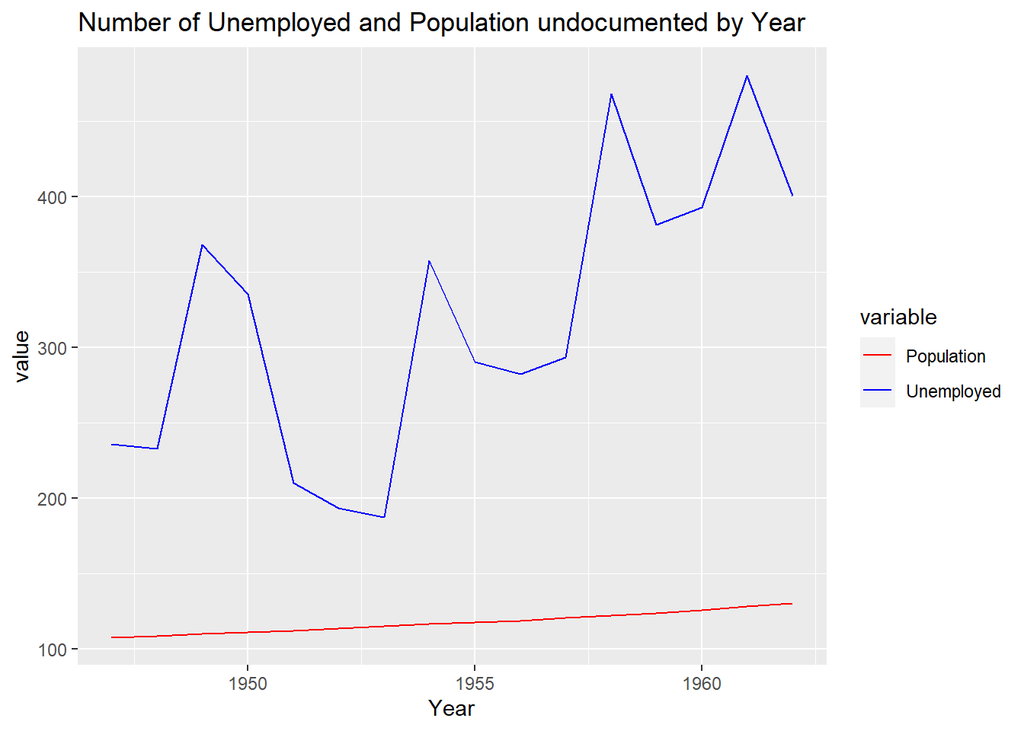

```r
df <- longley %>%
  select (Year, Unemployed, Population) %>%
  gather(key = "variable", value = "value", -Year)

ggplot(df, aes(x = Year, y = value)) +
  geom_line(aes(color = variable)) +
  scale_color_manual(values = c("red", "blue")) +
  ggtitle("Number of Unemployed and Population undocumented by Year")
```

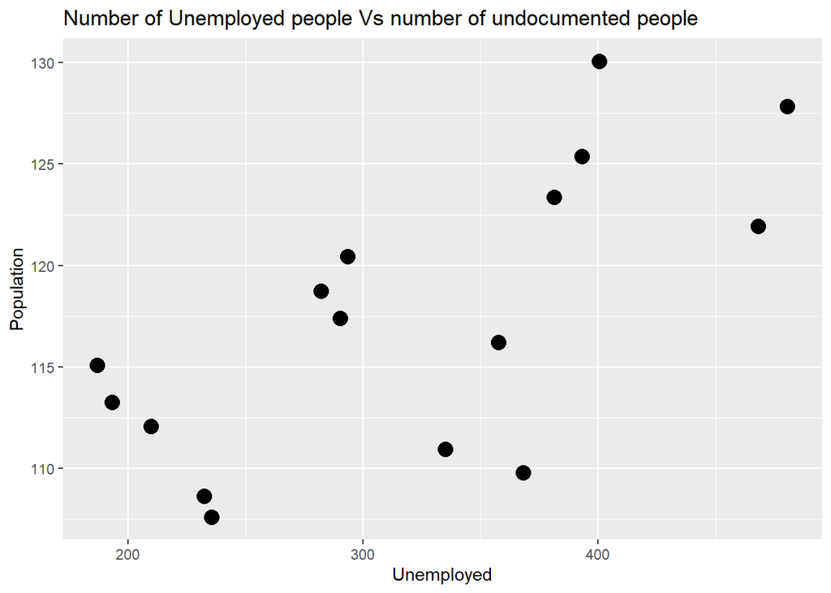

```r
ggplot(longley, aes(x = Unemployed, y = Population)) +
  geom_point(size = 4) +
  ggtitle("Number of Unemployed people Vs number of undocumented people")
```

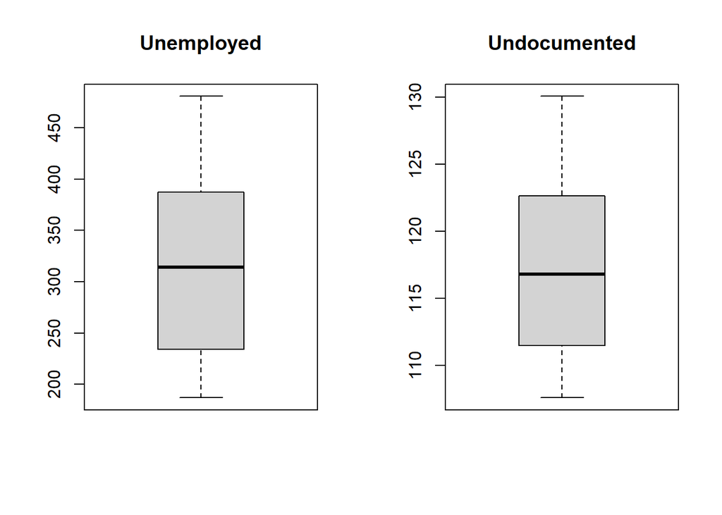

```r
par(mfrow=c(1,2))
boxplot(longley$Unemployed,main = "Unemployed")
boxplot(longley$Population,main = "Undocumented")
```

```r
mod <- lm(formula = Unemployed ~ Population, data=longley)
summary(mod)
```

```
##
## Call:
## lm(formula = Unemployed ~ Population, data = longley)
##
## Residuals:
##      Min       1Q   Median       3Q      Max
## -110.842  -50.308   -2.621   53.460  119.434
##
## Coefficients:
##             Estimate Std. Error t value Pr(>|t|)
## (Intercept) -763.665    307.033  -2.487  0.02610 *
## Population     9.223      2.610   3.533  0.00331 **
## ---
## Signif. codes:  0 '***' 0.001 '**' 0.01 '*' 0.05 '.' 0.1 ' ' 1
##
## Residual standard error: 70.33 on 14 degrees of freedom
## Multiple R-squared:  0.4714, Adjusted R-squared:  0.4336
## F-statistic: 12.48 on 1 and 14 DF,  p-value: 0.00331
```

### 6) Is there a correlation between the number of undocumented people and the evolution of the GNP?

#### For the last hypothesis we could think, based on the first graph, that there is a little correlation between the GNP and the number of undocumented people. However, the the next graph shows there is an important correlation between them, and it is proved by the p-value, so we can not reject the hypothesis.

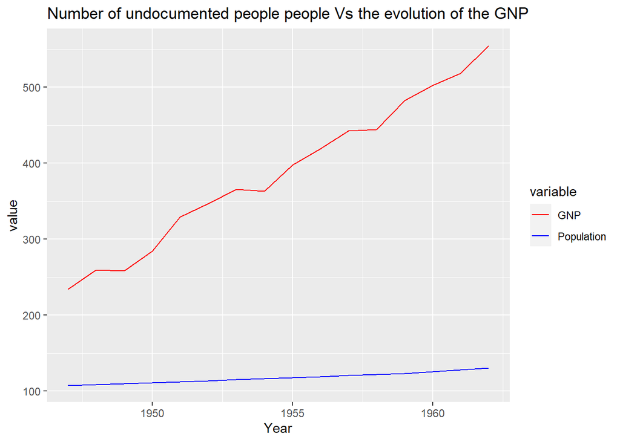

```r
df <- longley %>%
  select (Year, GNP, Population) %>%
  gather(key = "variable", value = "value", -Year)

ggplot(df, aes(x = Year, y = value)) +
  geom_line(aes(color = variable)) +
  scale_color_manual(values = c("red", "blue")) +
  ggtitle("Number of undocumented people people Vs the evolution of the GNP")
```

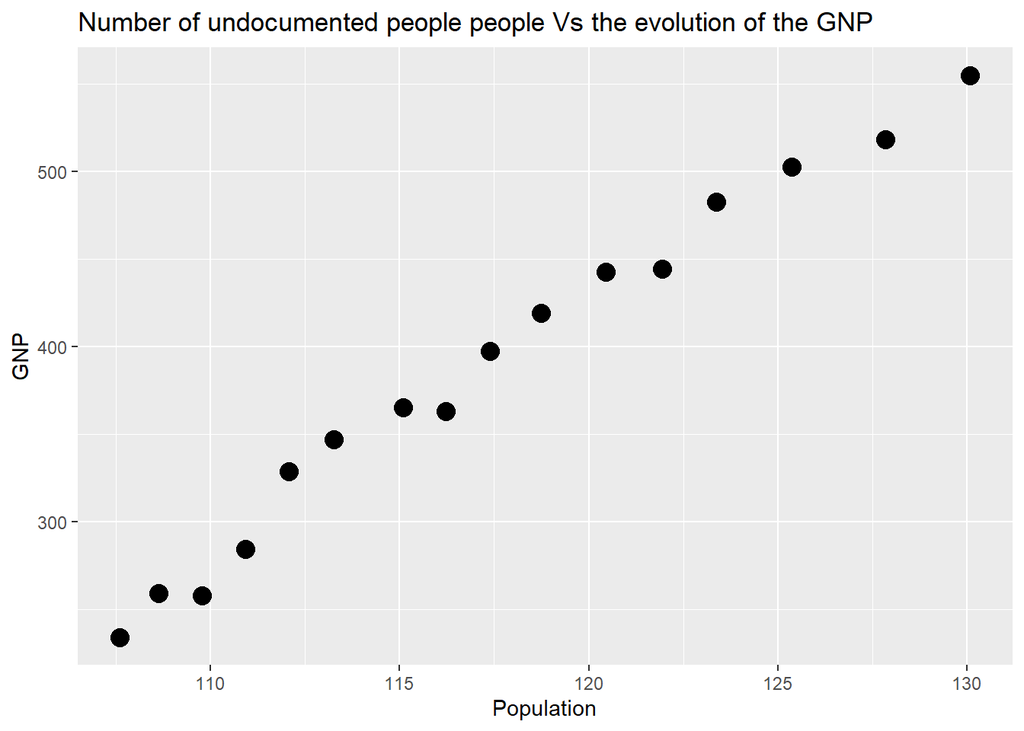

```r
ggplot(longley, aes(x = Population, y = GNP)) +
  geom_point(size = 4) +
  ggtitle("Number of undocumented people people Vs the evolution of the GNP")
```

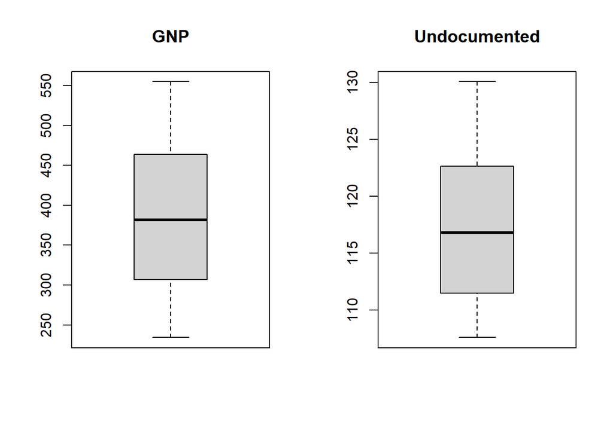

```r
par(mfrow=c(1,2))
boxplot(longley$GNP,main = "GNP")
boxplot(longley$Population,main = "Undocumented")
```

```r
mod <- lm(formula = GNP ~ Population, data=longley)
summary(mod)
```

```
##
## Call:
## lm(formula = GNP ~ Population, data = longley)
##
## Residuals:
##      Min       1Q   Median       3Q      Max
## -21.2942 -11.3519  -0.6804  11.2152  18.1277
##
## Coefficients:
##               Estimate Std. Error t value Pr(>|t|)
## (Intercept) -1275.2100    59.8256  -21.32 4.53e-12 ***
## Population     14.1616     0.5086   27.84 1.17e-13 ***
## ---
## Signif. codes:  0 '***' 0.001 '**' 0.01 '*' 0.05 '.' 0.1 ' ' 1
##
## Residual standard error: 13.7 on 14 degrees of freedom
## Multiple R-squared:  0.9823, Adjusted R-squared:  0.981
## F-statistic: 775.2 on 1 and 14 DF,  p-value: 1.168e-13
```

### 7) Is there a correlation between the GNP and the number of employed people?

#### However the hypothesis can not be rejected based on the p-value, so there is a correlation between these two parameters.

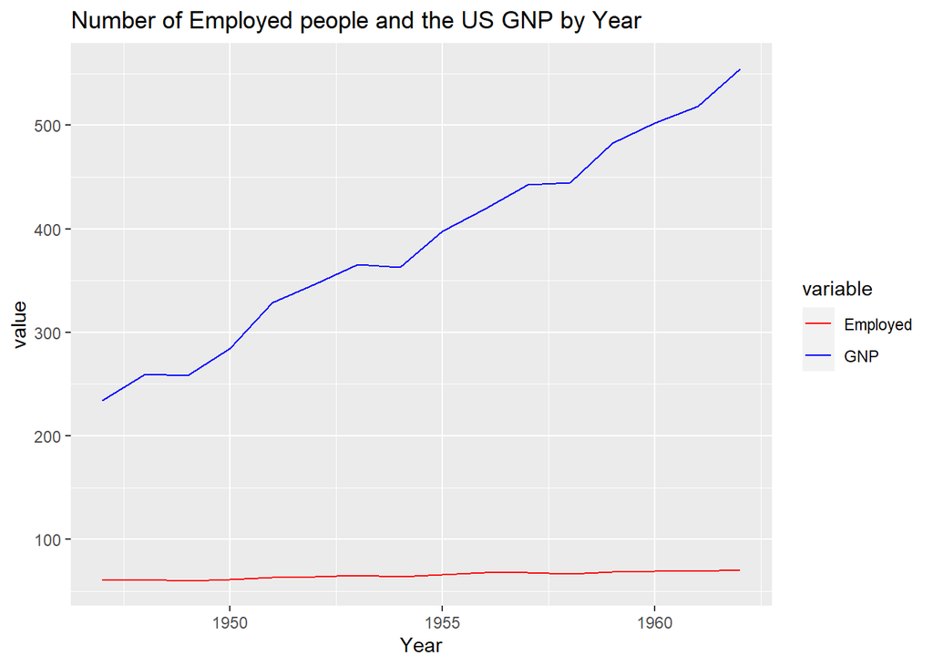

```r
df <- longley %>%
  select (Year, Employed, GNP) %>%
  gather(key = "variable", value = "value", -Year)

ggplot(df, aes(x = Year, y = value)) +
  geom_line(aes(color = variable)) +
  scale_color_manual(values = c("red", "blue")) +
  ggtitle("Number of Employed people and the US GNP by Year")
```

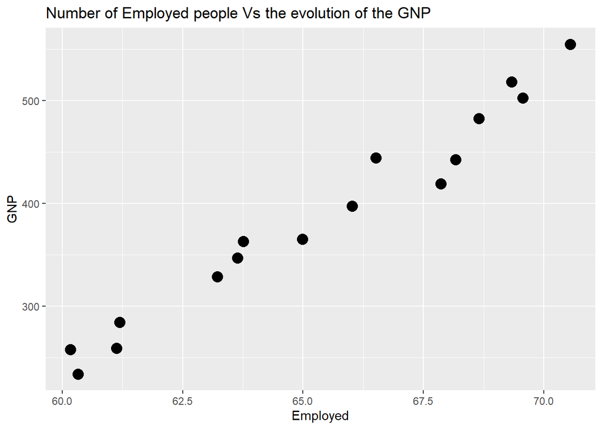

```r
ggplot(longley, aes(x = Employed, y = GNP)) +
  geom_point(size = 4) +
  ggtitle("Number of Employed people Vs the evolution of the GNP")
```

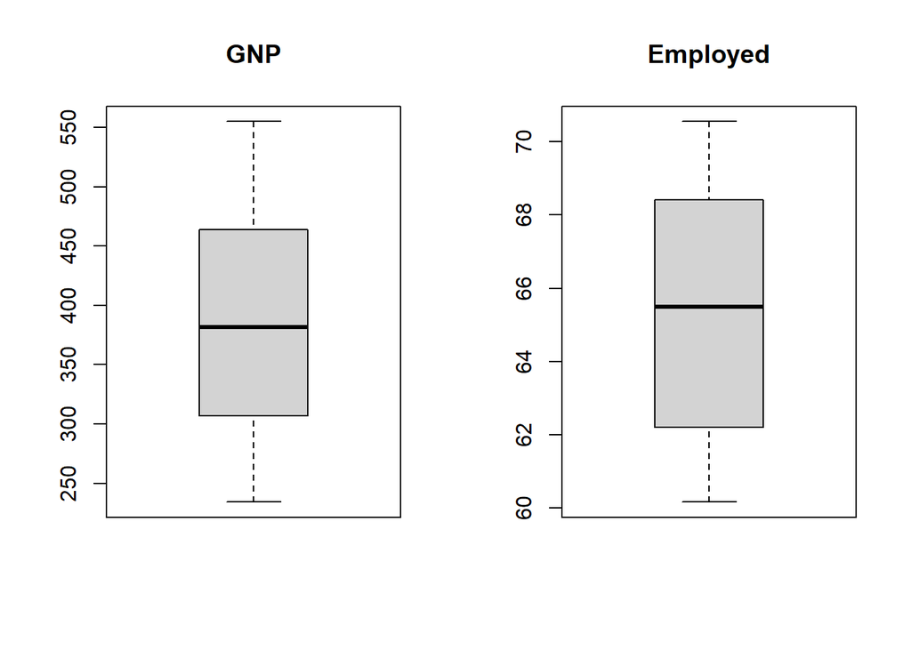

```r
par(mfrow=c(1,2))
boxplot(longley$GNP,main = "GNP")
boxplot(longley$Employed,main = "Employed")
```

```r
mod <- lm(formula = Employed ~ GNP, data=longley)
summary(mod)
```

```
##
## Call:
## lm(formula = Employed ~ GNP, data = longley)
##
## Residuals:
##      Min       1Q   Median       3Q      Max
## -0.77958 -0.55440 -0.00944  0.34361  1.44594
##
## Coefficients:
##              Estimate Std. Error t value Pr(>|t|)
## (Intercept) 51.843590   0.681372   76.09  < 2e-16 ***
## GNP          0.034752   0.001706   20.37 8.36e-12 ***
## ---
## Signif. codes:  0 '***' 0.001 '**' 0.01 '*' 0.05 '.' 0.1 ' ' 1
##
## Residual standard error: 0.6566 on 14 degrees of freedom
## Multiple R-squared:  0.9674, Adjusted R-squared:  0.965
## F-statistic: 415.1 on 1 and 14 DF,  p-value: 8.363e-12
```

### 8) Is there a correlation between the number of employed people and the number of employed people?

#### At first, we can think there is a small correlation between the number of employed people and the number of unemployed ones.

#### This is confirmed by the p-value, so the hypothesis is not rejected.

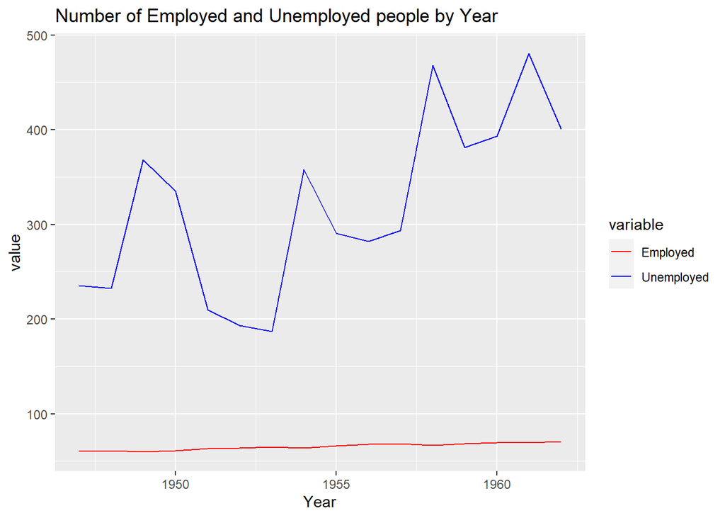

```r
df <- longley %>%
  select (Year, Unemployed, Employed) %>%
  gather(key = "variable", value = "value", -Year)


ggplot(df, aes(x = Year, y = value)) +
  geom_line(aes(color = variable)) +
  scale_color_manual(values = c("red", "blue")) +
  ggtitle("Number of Employed and Unemployed people by Year")
```

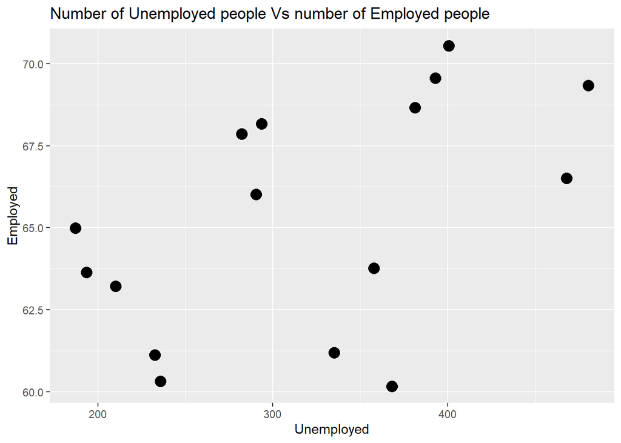

```r
ggplot(longley, aes(x = Unemployed, y = Employed)) +
  geom_point(size = 4) +
  ggtitle("Number of Unemployed people Vs number of Employed people")
```

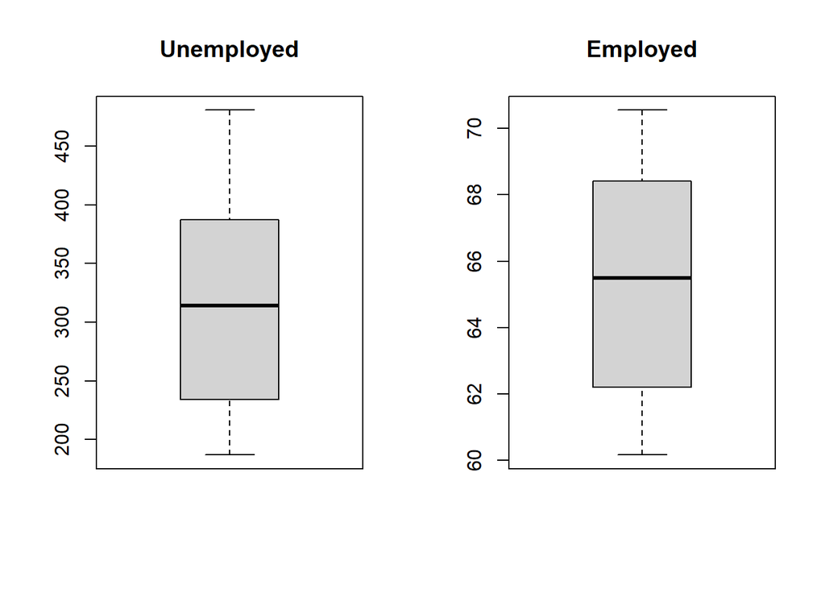

```r
par(mfrow=c(1,2))
boxplot(longley$Unemployed,main = "Unemployed")
boxplot(longley$Employed,main = "Employed")
```

```r
mod <- lm(formula = Unemployed ~ Employed, data=longley)
summary(mod)
```

```
##
## Call:
## lm(formula = Unemployed ~ Employed, data = longley)
##
## Residuals:
##      Min       1Q   Median       3Q      Max
## -127.946  -65.671   -2.786   62.202  132.778
##
## Coefficients:
##             Estimate Std. Error t value Pr(>|t|)
## (Intercept) -553.987    402.130  -1.378   0.1899
## Employed      13.370      6.148   2.175   0.0473 *
## ---
## Signif. codes:  0 '***' 0.001 '**' 0.01 '*' 0.05 '.' 0.1 ' ' 1
##
## Residual standard error: 83.63 on 14 degrees of freedom
## Multiple R-squared:  0.2525, Adjusted R-squared:  0.1991
## F-statistic: 4.729 on 1 and 14 DF,  p-value: 0.04729
```

# Fitting Model

#### we will not treat the rejected hypothesis

### 1) Is there a correlation between the number of unemployed people and the ones in the armed forces?

[figure not shown]

```r
ggplot(newDataFrame, aes(x = army, y = unemployed)) +
  geom_point(size = 4) +
  labs(y = "Unemployed", x = "Armed.Forces") +
  geom_smooth(method = "lm", formula = y ~ x, se = FALSE) +
  geom_text(x = 350, y = 470, label = "y = 0.5 * x + 200", color = "blue", size = 5) +
  ggtitle("Number of people in the armed forces Vs the number of unemployed people")
```

```r
mod <- lm(formula = army ~ unemployed, data=newDataFrame)
summary(mod)
```

```
##
## Call:
## lm(formula = army ~ unemployed, data = newDataFrame)
##
## Residuals:
##     Min      1Q  Median      3Q     Max
## -84.165 -17.591   8.031  24.555  83.432
##
## Coefficients:
##             Estimate Std. Error t value Pr(>|t|)
## (Intercept) 245.5729    48.6844   5.044 0.000504 ***
## unemployed    0.5637     0.1423   3.962 0.002676 **
## ---
## Signif. codes:  0 '***' 0.001 '**' 0.01 '*' 0.05 '.' 0.1 ' ' 1
##
## Residual standard error: 47.8 on 10 degrees of freedom
## Multiple R-squared:  0.6109, Adjusted R-squared:  0.572
## F-statistic:  15.7 on 1 and 10 DF,  p-value: 0.002676
```

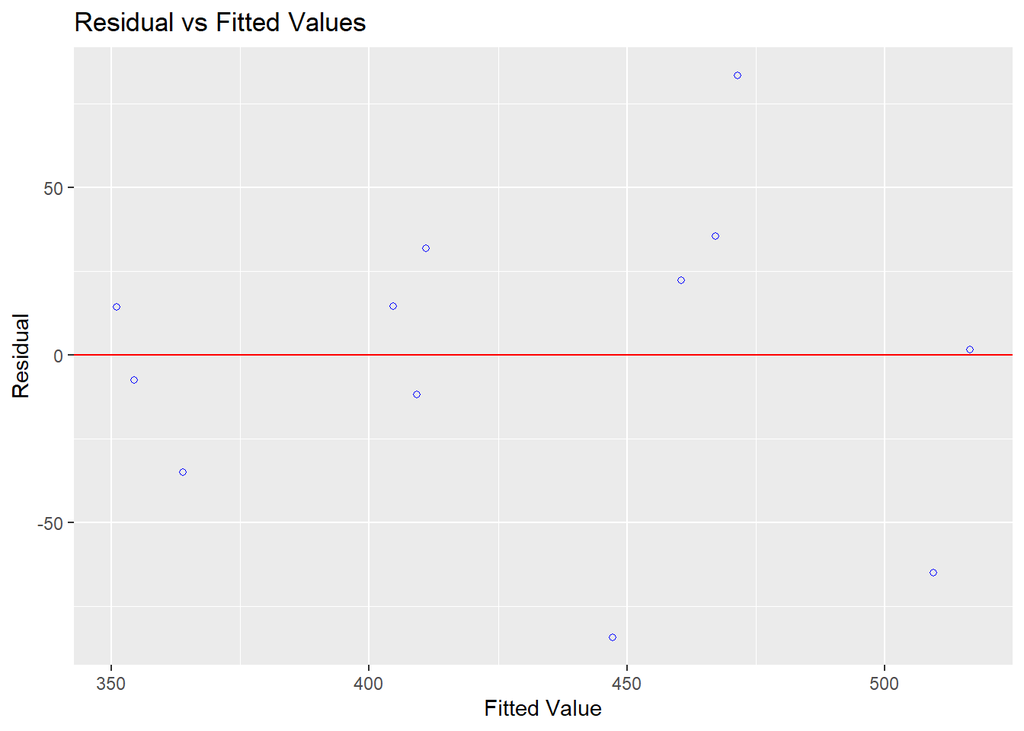

```r
model <- lm(army ~ unemployed, data=newDataFrame)
ols_plot_resid_fit(model)
```

#### We can see the residual standard error is very high, a little below 50, meaning the model will not be very accurate. However, the value of r-squared is equalled to 0.6, meaning the model is still a good one, but not an enough one because we need it to be above 0.7. Therefore, we can not validate the hypothesis.

#### Because the hypothesis is not validate, we will not do some predictions.